# Demographic Momentum: The Hidden Force Shaping America’s Future

Census Data Analysis

2025-07-21

## The Physics of Population Change

Demographics operate like physics—populations in motion tend to stay in motion. A county filled with young families generates momentum through births and economic activity that persists for decades. An aging rural county loses momentum as deaths outnumber births and young adults migrate away, creating a self-reinforcing cycle of decline that proves difficult to reverse.

This analysis quantifies demographic momentum across **2,825** American counties, combining age structure, migration patterns, and economic indicators to identify places where demographic forces are building versus places where they’re stalling. The results reveal which communities are positioned for growth and which face structural demographic headwinds.

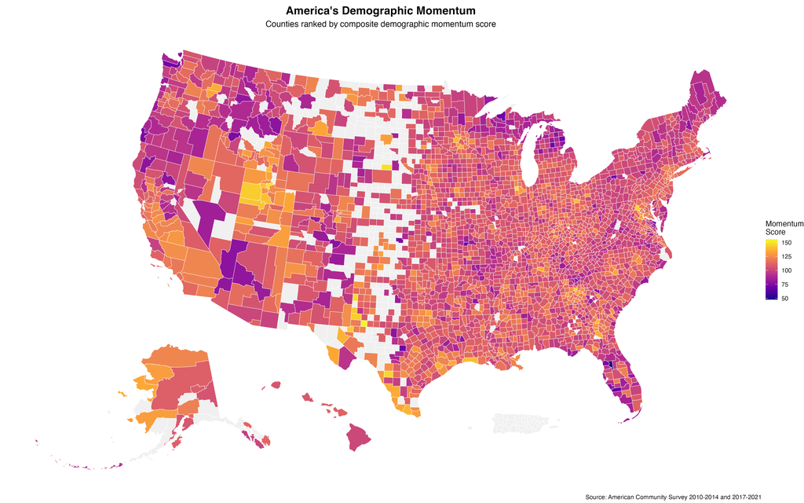

America’s demographic momentum reveals clear regional patterns, with high momentum concentrating in the South and West while parts of the Midwest and Northeast show lower momentum scores

The national momentum map reveals **Utah’s exceptional demographic dynamism**, **Texas’s sustained growth potential**, and **rural Midwest counties** facing structural demographic challenges. These patterns reflect decades of demographic forces that will shape population distributions for generations to come.

## The Mechanics of Momentum

Demographic momentum operates through three interconnected mechanisms that this analysis measures systematically:

**Age Structure Momentum** - Counties with large populations of children and young adults generate future growth through family formation and workforce entry. A high ratio of working-age to retirement-age residents indicates sustainable momentum.

**Migration Momentum** - Places attracting migrants, especially educated migrants, demonstrate economic vitality that compounds demographic growth. Interstate and international migration patterns reveal where Americans vote with their feet.

**Economic Momentum** - Recent housing construction and high-skill employment indicate economic conditions that support population growth. Counties building infrastructure and attracting knowledge workers demonstrate sustainable momentum.

Counties with the Strongest Demographic Momentum by Size Category (2012-2021)

| County | State | Size Category | Momentum Score | Annual Growth Rate (%) | 2021 Population |
| --- | --- | --- | --- | --- | --- |
| Kendall County | Illinois | Large County (100k+) | 149.7 | 1.51 | 130,757 |
| Loudoun County | Virginia | Large County (100k+) | 145.4 | 3.07 | 413,574 |
| Forsyth County | Georgia | Large County (100k+) | 143.9 | 3.71 | 245,754 |
| Utah County | Utah | Large County (100k+) | 140.6 | 2.56 | 648,265 |
| Davis County | Utah | Large County (100k+) | 140.4 | 1.76 | 358,831 |
| Delaware County | Ohio | Large County (100k+) | 138.6 | 2.14 | 211,121 |
| Wright County | Minnesota | Large County (100k+) | 138.5 | 1.28 | 139,890 |
| Hidalgo County | Texas | Large County (100k+) | 137.6 | 1.24 | 865,677 |
| Fort Bend County | Texas | Large County (100k+) | 136.9 | 3.58 | 806,497 |
| Williamson County | Tennessee | Large County (100k+) | 136.7 | 3.10 | 242,386 |
| Tooele County | Utah | Medium County (25k-100k) | 143.5 | 2.30 | 71,340 |
| Oldham County | Kentucky | Medium County (25k-100k) | 138.1 | 1.26 | 67,586 |
| Chambers County | Texas | Medium County (25k-100k) | 134.3 | 3.04 | 45,257 |
| Uintah County | Utah | Medium County (25k-100k) | 133.5 | 0.88 | 35,488 |
| Starr County | Texas | Medium County (25k-100k) | 133.4 | 0.83 | 65,568 |
| Jefferson County | Idaho | Medium County (25k-100k) | 133.2 | 1.79 | 30,427 |
| Franklin County | Washington | Medium County (25k-100k) | 133.1 | 2.15 | 95,313 |
| Holmes County | Ohio | Medium County (25k-100k) | 131.4 | 0.43 | 44,166 |
| Dallas County | Iowa | Medium County (25k-100k) | 131.4 | 4.15 | 96,604 |
| Oconee County | Georgia | Medium County (25k-100k) | 131.3 | 2.51 | 41,006 |
| Martin County | Texas | Small County (<25k) | 155.4 | 0.91 | 5,213 |
| Morgan County | Utah | Small County (<25k) | 148.9 | 2.80 | 12,162 |
| Todd County | South Dakota | Small County (<25k) | 148.7 | -0.32 | 9,434 |
| Bailey County | Texas | Small County (<25k) | 148.6 | -0.20 | 6,968 |
| Zavala County | Texas | Small County (<25k) | 146.5 | -1.89 | 9,900 |
| Gaines County | Texas | Small County (<25k) | 143.8 | 2.09 | 21,167 |
| Winkler County | Texas | Small County (<25k) | 143.3 | 0.74 | 7,629 |
| Yoakum County | Texas | Small County (<25k) | 141.9 | -0.30 | 7,707 |
| Juab County | Utah | Small County (<25k) | 141.7 | 1.45 | 11,648 |
| Franklin County | Idaho | Small County (<25k) | 139.9 | 1.08 | 14,036 |

**Utah counties dominate** the top momentum rankings—**Morgan**, **Tooele**, **Juab**, **Utah**, and **Davis** counties all appear in the top 15. This reflects Utah’s unique combination of high birth rates, young age structure, robust in-migration, and economic diversification that creates sustained demographic momentum.

**Loudoun County, Virginia** and **Forsyth County, Georgia** represent suburban momentum—counties benefiting from metropolitan expansion where growing job markets attract young families, generating both natural increase and net in-migration. These counties demonstrate how proximity to major urban areas creates sustained demographic momentum through economic opportunity.

## Validating Momentum Predictions

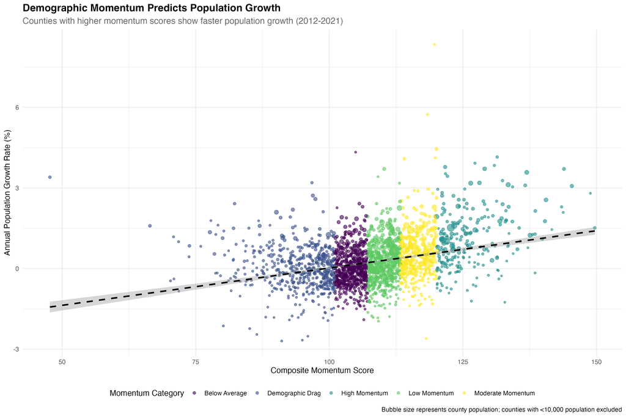

Counties with higher momentum scores showed faster population growth from 2012-2021, validating the predictive power of demographic momentum analysis

The momentum framework proves predictive: counties with higher momentum scores achieved faster population growth over the subsequent decade. The correlation coefficient of **0.302** confirms that demographic momentum successfully identifies counties positioned for growth versus decline.

**Forward-Looking Metric**: Importantly, momentum measures demographic potential rather than current growth rates. Counties with high momentum scores but moderate growth rates represent places with strong underlying demographic foundations—young age structures, in-migration patterns, and economic conditions—that position them for sustained future growth even if current population changes appear modest.

Importantly, some counties show high momentum scores but moderate growth rates, suggesting demographic potential that may realize over longer time horizons. Others show lower momentum but stable growth, indicating mature communities with balanced demographic profiles.

## The State Geography of Momentum

States ranked by average county demographic momentum

| State | Counties | Avg Momentum Score | Avg Growth Rate (%) | % High Momentum |
| --- | --- | --- | --- | --- |
| Utah | 25 | 127.0 | 1.213 | 76.0 |
| Alaska | 16 | 113.4 | 0.310 | 31.2 |
| New Jersey | 21 | 113.0 | 0.360 | 9.5 |
| Texas | 203 | 112.0 | 0.400 | 24.6 |
| Georgia | 151 | 111.0 | 0.219 | 21.2 |
| Idaho | 37 | 110.9 | 0.946 | 29.7 |
| Louisiana | 63 | 110.7 | -0.252 | 12.7 |
| Mississippi | 80 | 110.5 | -0.431 | 11.2 |
| California | 56 | 110.0 | 0.481 | 25.0 |
| Ohio | 88 | 109.5 | -0.049 | 4.5 |
| North Dakota | 24 | 109.4 | 1.071 | 12.5 |
| Indiana | 92 | 109.4 | 0.063 | 8.7 |
| Kentucky | 116 | 109.2 | 0.040 | 7.8 |
| Minnesota | 83 | 109.0 | 0.195 | 8.4 |
| Nebraska | 56 | 108.5 | -0.010 | 5.4 |

**Utah** emerges as America’s most momentum-rich state with an average county score of 127.1, reflecting the state’s unique demographic profile of high birth rates, young age structure, strong in-migration, and diversified economic growth. Utah’s Mormon cultural influence on family formation combines with technology sector growth to create exceptional demographic dynamism. With 76% of Utah counties classified as high momentum, the state demonstrates remarkable consistency in demographic vitality.

**Texas** appears prominently due to its scale—203 counties provide substantial geographic diversity, but oil field developments, urban expansion, and international migration create momentum across rural and urban areas alike. The state exemplifies how energy development and population growth reinforce each other.

**Alaska** and **North Dakota** demonstrate resource boom momentum, where oil and gas development creates employment opportunities that attract young workers and generate rapid population growth in previously declining areas.

**New Jersey** represents suburban momentum near major metropolitan areas, where proximity to New York and Philadelphia job markets combined with family-friendly communities creates sustained demographic momentum despite high costs.

## Regional Patterns in American Momentum

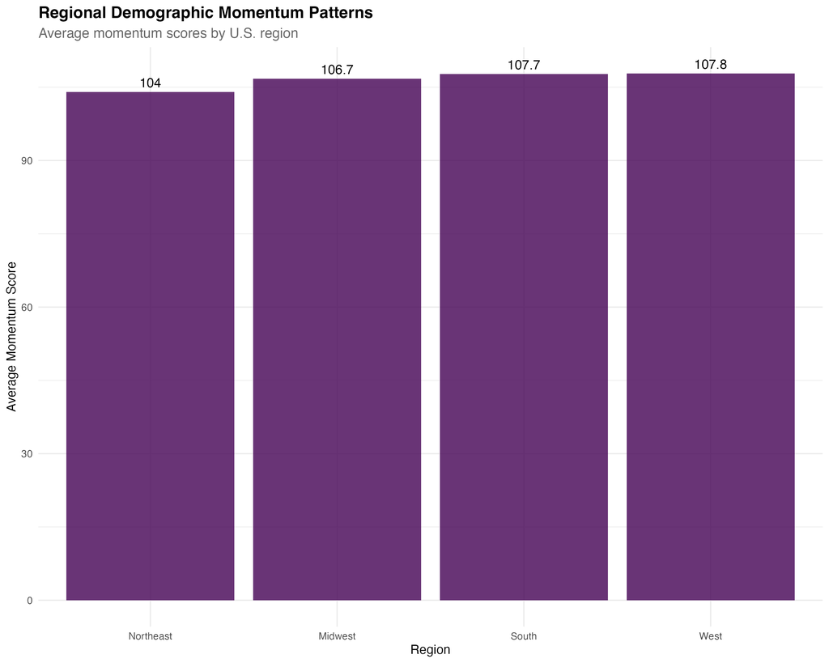

Regional demographic momentum patterns reveal the West and South leading in population dynamics while the Northeast and Midwest show signs of demographic maturation

Regional demographic momentum patterns across America

| Region | Counties | Avg Momentum Score | Avg Growth Rate (%) | % High Momentum | % Demographic Drag |
| --- | --- | --- | --- | --- | --- |
| West | 366 | 107.8 | 0.609 | 19.7 | 30.9 |
| South | 1342 | 107.7 | 0.114 | 10.7 | 23.6 |
| Midwest | 901 | 106.7 | -0.038 | 6.8 | 23.3 |
| Northeast | 216 | 104.0 | 0.049 | 1.9 | 31.0 |

The **Northeast** shows the lowest regional momentum (104.0), reflecting demographic maturation, high costs, and out-migration to other regions. However, this doesn’t indicate uniform decline—many northeastern counties maintain stable or growing populations through economic specialization.

## Components of Demographic Momentum

[figure not shown]

**Age Structure** - High momentum counties maintain younger age profiles with larger childbearing-age populations and favorable dependency ratios. These counties avoid the demographic trap where deaths begin outnumbering births.

**Migration** - High momentum places attract migrants from other states and internationally, indicating economic opportunities and quality of life factors that draw people. Educational attainment of migrants amplifies economic benefits.

**Economic Indicators** - Recent housing construction, high-skill employment, and income levels demonstrate the economic foundation necessary to support population growth. Without economic opportunity, demographic momentum stalls regardless of age structure.

## Planning Implications for Momentum Counties

Counties with strong demographic momentum face different planning challenges than those with demographic drag:

**Infrastructure Scaling** - High momentum counties must rapidly expand schools, roads, water systems, and other infrastructure to accommodate growing populations. **Utah County, Utah** and **Loudoun County, Virginia** exemplify communities managing rapid growth.

**Housing Development** - Momentum counties require significant housing construction to accommodate in-migrants and family formation. Failure to provide adequate housing creates affordability crises that can stall momentum.

**Service Provision** - Growing counties must hire teachers, police officers, firefighters, and other service personnel at rates that exceed population growth to maintain service levels during rapid expansion.

**Fiscal Planning** - Momentum counties often show strong property tax growth but face front-loaded infrastructure investments that require careful financial management to avoid unsustainable debt burdens.

## The Challenge of Declining Momentum

While this analysis focused on identifying high momentum areas, the absence of momentum creates equally important policy challenges:

**Demographic Drag Counties** - Rural areas with aging populations, limited economic opportunities, and persistent out-migration face compound challenges where population decline reduces tax bases needed to maintain infrastructure and services.

**Service Delivery Challenges** - Counties losing population must maintain infrastructure sized for historical peaks while serving smaller populations, creating unsustainable per-capita costs.

**Economic Development Obstacles** - Low momentum counties struggle to attract businesses when workforce populations are declining and aging, creating self-reinforcing cycles of economic stagnation.

## Methodology and Validation

This analysis represents a significant methodological advance over previous demographic studies by:

**Multi-Dimensional Measurement** - Rather than relying on single indicators like population growth rates, the framework combines age structure, migration patterns, and economic conditions into comprehensive momentum scores.

**Geographic Comprehensiveness** - County-level analysis across all U.S. counties provides systematic identification of momentum patterns invisible at state or regional levels.

**Policy Relevance** - Focus on predictive momentum rather than historical growth provides forward-looking information for infrastructure planning, economic development, and service delivery decisions.

## Conclusion: Embracing Demographic Physics

Demographic momentum operates as a fundamental force shaping American communities, but unlike physical momentum, demographic patterns can be influenced through policy interventions. Counties that understand their momentum trajectories can plan infrastructure, attract investment, and implement policies that either accelerate positive momentum or mitigate negative trends.

**High momentum counties** like those in Utah, Texas, and suburban growth areas should focus on managing rapid growth sustainably—expanding infrastructure efficiently, maintaining quality of life during expansion, and avoiding boom-bust cycles that can stall momentum.

**Moderate momentum counties** have opportunities to strengthen their demographic position through targeted economic development, education investment, and quality of life improvements that can tip demographic trends in positive directions.

**Low momentum counties** face more challenging but not impossible situations—strategic investments in broadband infrastructure, rural healthcare, education, and amenities can help retain young adults and attract newcomers even in demographically challenging areas.